# The easing of lockdown in Glasgow

## Nick Bailey, UBDC - 28/04/2021

On Monday 26th April, some of the lockdown restrictions were eased in Scotland. In particular, non-essential shops were allowed to re-open, and pubs and restaurants could offer food inside. Similar changes had occurred in England two weeks earlier.

In Glasgow, we can look at the impacts of these changes thanks to a unique partnership between the Urban Big Data Centre, Glasgow City Council and the Glasgow Centre for Population Health. As explained in an earlier blog (https://www.ubdc.ac.uk/news-media/2020/july/creating-open-data-counts-of-pedestrians-and-vehicles-using-cctv-cameras/), UBDC is using spare capacity in the CCTV system to analyse images captured at regular intervals for set locations. Our software produces counts of the number of pedestrians present in these images. These data are then made publicly available providing a near-real-time picture of footall across the city.

In the figures below, we use these data to compare average daily counts of pedestrians between 10am and 4pm. The most recent week (in red) is compared with the averages for the same days over the previous eight weeks (in grey).

## City centre

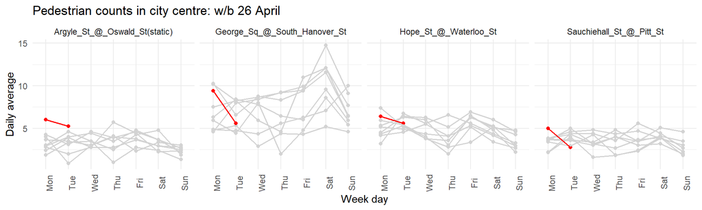

## Other high street locations

In addition to the city centre, we have data for ‘high street’ locations such as Byres Road, Duke Street, Maryhill Road and Victoria Road.

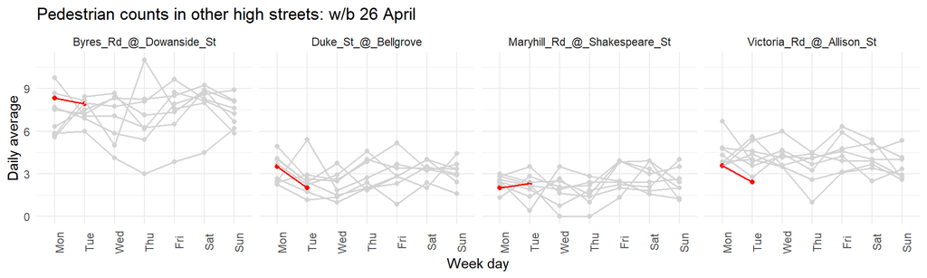

## Parks

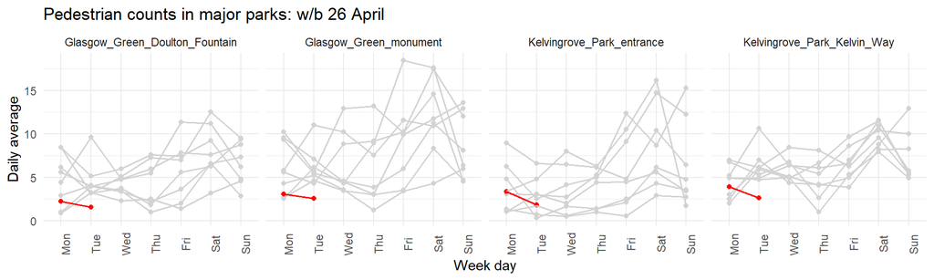

## The riverfront

Glasgow’s riverfront has also been a popular destination over lockdown for walking, cycling or just hanging out.

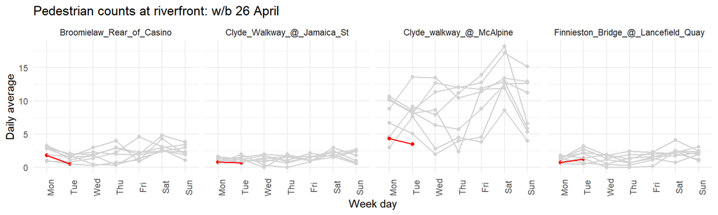

## Further information

The data from the CCTV analysis are available here as open data: https://api.ubdc.ac.uk/cctv/. The code to re-produce this analysis is available here: https://github.com/nick-bailey/UBDC-CCTV-data.